# R Notebook

```r
library(dplyr)
library(caret)
library(RWeka)
library(rpart)
library(rpart.plot)
library(class)
library(gmodels)
library(ROCR)
library(AUC)
library(gmodels)
library(e1071)
library(factoextra)
library(party)
library(RColorBrewer)
library(plyr)
library(tidyverse)
library(cluster)
library(dbscan)

library(fpc)
```

Reading all pubg data files

Checking if all data frames have column names in the correct order

Combining all data frames to one

Removing deaths that occured by dying in the blue zone, falling or down and out

separating data based on maps

Combining all the 4 data sets to one

*Data cleaning*

See different unique values in the “killed by” column. These will give us the modes in which the victim was killed

We remove N/A values, positional values which have 0.0 and weapons we cannot identify

We write a new .csv file which contains the cleaned data

Reading the cleaned data

```r
cleandata <- read.csv("cleanerangel.csv", header = TRUE, stringsAsFactors = FALSE)
```

Data Manupilation process

```r
#feature engineering: deriving a feature
cleandata$GunType <- 0
cleandata$killerelevation <- 0
cleandata$victimelevation <- 0
cleandata$killdistance <- 0

mysample <- cleandata #[sample(1:nrow(cleandata), 30000,replace=FALSE),]

Rifle <- c("Groza", "M16A4", "Mk14", "SCAR-L", "M416", "Mini 14", "AKM", "AUG")
MG <- c("M249", "DP-28")
Sniper <- c("AWM", "Kar98k", "M24", "Crossbow", "SKS")
Explosives <- c("Grenade", "death.ProjMolotov_C", "death.ProjMolotov_DamageField_C")
Vehicles <- c("Boat", "Buggy", "Hit by Car", "Motorbike", "Motorbike (SideCar)", "Dacia", "Aquarail", "Uaz")
SMG <- c("Micro UZI", "UMP9", "Tommy Gun", "Vector", "VSS")
Melee <- c("Crowbar", "Machete", "Pan", "Sickle", "Punch", "death.WeapSawnoff_C")
Pistols <- c("P18C", "P1911", "P92", "R1895", "R45")
Shotgun <- c("S12K", "S1897", "S686")


mysample <- within(mysample, GunType[killed_by %in% Rifle] <- ("Rifle"))
mysample <- within(mysample, GunType[killed_by %in% MG] <- ("Machine Gun"))
mysample <- within(mysample, GunType[killed_by %in% Sniper] <- ("Sniper"))
mysample <- within(mysample, GunType[killed_by %in% Explosives] <- ("Explosives"))
mysample <- within(mysample, GunType[killed_by %in% Vehicles] <- ("Vehicles"))
mysample <- within(mysample, GunType[killed_by %in% Melee] <- ("Melee"))
mysample <- within(mysample, GunType[killed_by %in% Shotgun] <- ("Shotgun"))
mysample <- within(mysample, GunType[killed_by %in% Pistols] <- ("Pistol"))
mysample <- within(mysample, GunType[killed_by %in% SMG] <- ("Sub Machine Gun"))



mysample <- within(mysample, killerelevation[killer_position_x > 462500 & killer_position_x < 500000  & killer_position_y > 110000 & killer_position_x < 131500] <- ("Elevated"))
mysample <- within(mysample, killerelevation[killer_position_x > 337500 & killer_position_x < 581500  & killer_position_y > 187500 & killer_position_x < 237500] <- ("Elevated"))
mysample <- within(mysample, killerelevation[killer_position_x > 562500 & killer_position_x < 662500  & killer_position_y > 350000 & killer_position_x < 450000] <- ("Elevated"))
mysample <- within(mysample, killerelevation[killer_position_x > 181200 & killer_position_x < 262500  & killer_position_y > 450000 & killer_position_x < 525000] <- ("Elevated"))
mysample <- within(mysample, killerelevation[killer_position_x > 462500 & killer_position_x < 631500  & killer_position_y > 600000 & killer_position_x < 750000] <- ("Elevated"))
mysample <- within(mysample, killerelevation[killer_position_x > 100000 & killer_position_x < 150000  & killer_position_y > 650000 & killer_position_x < 700000] <- ("Elevated"))
mysample <- within(mysample, killerelevation[killer_position_x > 875000 & killer_position_x < 250000  & killer_position_y > 225000 & killer_position_x < 381250] <- ("Elevated"))

mysample <- within(mysample, killerelevation[killerelevation == 0] <- ("Normal"))

mysample <- within(mysample, victimelevation[victim_position_x > 462500 & victim_position_x < 500000  & victim_position_y > 110000 & victim_position_x < 131500] <- ("Elevated"))
mysample <- within(mysample, victimelevation[victim_position_x > 337500 & victim_position_x < 581500  & victim_position_y > 187500 & victim_position_x < 237500] <- ("Elevated"))
mysample <- within(mysample, victimelevation[victim_position_x > 562500 & victim_position_x < 662500  & victim_position_y > 350000 & victim_position_x < 450000] <- ("Elevated"))
mysample <- within(mysample, victimelevation[victim_position_x > 181200 & victim_position_x < 262500  & victim_position_y > 450000 & victim_position_x < 525000] <- ("Elevated"))
mysample <- within(mysample, victimelevation[victim_position_x > 462500 & victim_position_x < 631500  & victim_position_y > 600000 & victim_position_x < 750000] <- ("Elevated"))
mysample <- within(mysample, victimelevation[victim_position_x > 100000 & victim_position_x < 150000  & victim_position_y > 650000 & victim_position_x < 700000] <- ("Elevated"))
mysample <- within(mysample, victimelevation[victim_position_x > 875000 & victim_position_x < 250000  & victim_position_y > 225000 & victim_position_x < 381250] <- ("Elevated"))

mysample <- within(mysample, victimelevation[victimelevation == 0] <- ("Normal"))

mysample <- within(mysample, killdistance[killdistance == 0] <- sqrt(((killer_position_x - victim_position_x)^2) + ((killer_position_y - victim_position_y)^2)))
```

Converting the derived features to factors for analysis

```r
mysample$killed_by <- as.factor(mysample$killed_by)
mysample$GunType <- as.factor(mysample$GunType)
mysample$killerelevation <- as.factor(mysample$killerelevation)
mysample$victimelevation <- as.factor(mysample$victimelevation)
```

Removing the row which contains row numbers

```r
mysample <- mysample[,-1]
str(mysample)
```

```
'data.frame':   39705577 obs. of  10 variables:
 $ killer_position_x: num  496990 460417 488034 501063 495501 ...
 $ killer_position_y: num  312570 414749 347220 425079 429826 ...
 $ victim_position_x: num  497819 459818 487444 493043 495756 ...
 $ victim_position_y: num  331981 414426 347651 434458 438322 ...
 $ killed_by        : Factor w/ 45 levels "AKM","Aquarail",..: 18 1 1 40 21 21 36 21 1 30 ...
 $ time             : int  1035 1422 1210 1818 1766 1579 105 1881 405 279 ...
 $ GunType          : Factor w/ 9 levels "Explosives","Machine Gun",..: 5 5 5 7 5 5 6 5 5 4 ...
 $ killerelevation  : Factor w/ 2 levels "Elevated","Normal": 2 2 2 2 2 2 2 2 2 2 ...
 $ victimelevation  : Factor w/ 2 levels "Elevated","Normal": 2 2 2 2 2 2 2 2 2 2 ...
 $ killdistance     : num  19429 680 730 12340 8500 ...
```

```r
set.seed(2334)
mysample1 <- mysample[sample(1:nrow(cleandata), 30000,replace=FALSE),]

set.seed(553)
mysample2 <- mysample[sample(1:nrow(cleandata), 30000,replace=FALSE),]

set.seed(9876)
mysample3 <- mysample[sample(1:nrow(cleandata), 30000,replace=FALSE),]

write.csv(mysample1, "sample1.csv")
write.csv(mysample2, "sample2.csv")
write.csv(mysample3, "sample3.csv")
```

Creating another data set samples the same way but with scaled data

```r
set.seed(2334)
smysample1 <- mysample[sample(1:nrow(cleandata), 30000,replace=FALSE),]

set.seed(553)
smysample2 <- mysample[sample(1:nrow(cleandata), 30000,replace=FALSE),]

set.seed(9876)
smysample3 <- mysample[sample(1:nrow(cleandata), 30000,replace=FALSE),]


preProcValues <- preProcess(x = smysample1,method = c("center", "scale"))
smysample1 <- predict(preProcValues, smysample1)
```

Creating histogram charts and check the frequency of the class of guns used and also check if terrain is elevated or normal

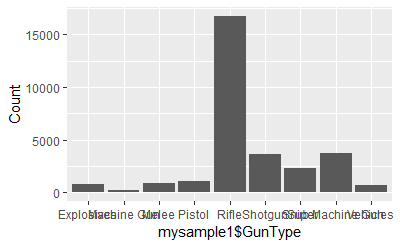

```r
histo_charts(mysample1, mysample1$GunType)
```

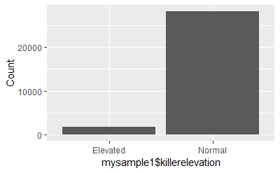

```r
histo_charts(mysample1, mysample1$killerelevation)
```

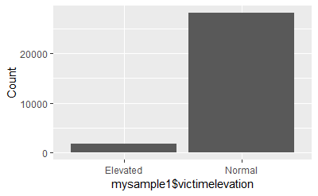

```r
histo_charts(mysample1, mysample1$victimelevation)
```

Histograms for sample 1

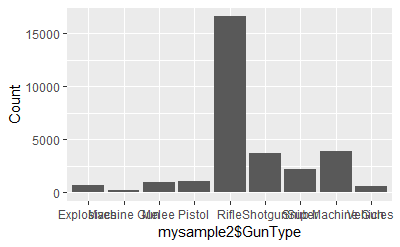

```r
histo_charts(mysample2, mysample2$GunType)
```

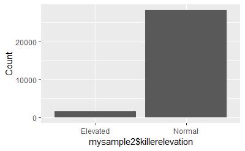

```r
histo_charts(mysample2, mysample2$killerelevation)
```

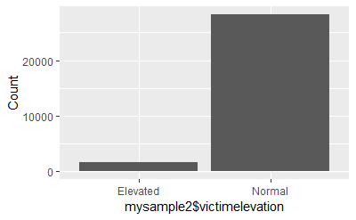

```r
histo_charts(mysample2, mysample2$victimelevation)
```

Histograms for sample 2

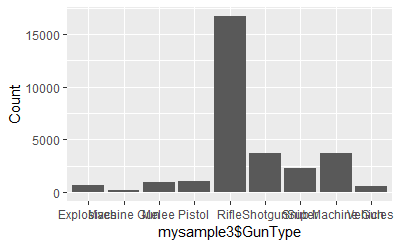

```r
histo_charts(mysample3, mysample3$GunType)
```

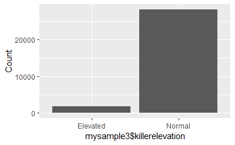

```r
histo_charts(mysample3, mysample3$killerelevation)
```

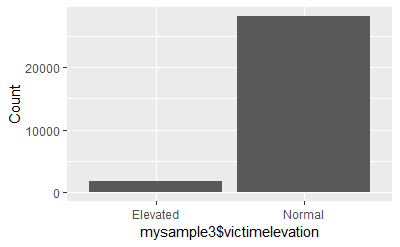

```r
histo_charts(mysample3, mysample3$victimelevation)
```

Histogram for sample 3

```r
histo_charts(mysample3, mysample3$GunType)
histo_charts(mysample3, mysample3$killerelevation)
histo_charts(mysample3, mysample3$victimelevation)
```

[output not shown]

Creating function for scatterplot diagram

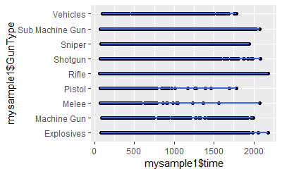

```r
scatterplot_func(mysample1, mysample1$time, mysample1$GunType)
```

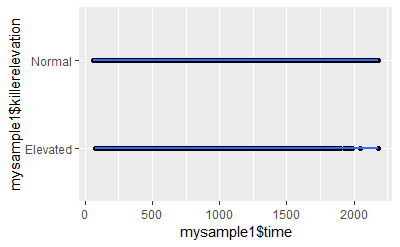

```r
scatterplot_func(mysample1, mysample1$time, mysample1$killerelevation)
```

Creating scatterplots

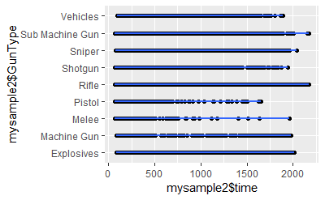

```r
scatterplot_func(mysample2, mysample2$time, mysample2$GunType)
```

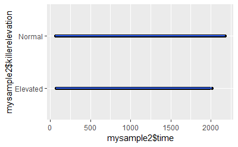

```r
scatterplot_func(mysample2, mysample2$time, mysample2$killerelevation)
```

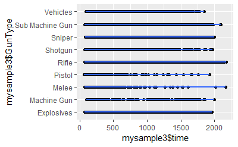

```r
scatterplot_func(mysample3, mysample3$time, mysample3$GunType)
```

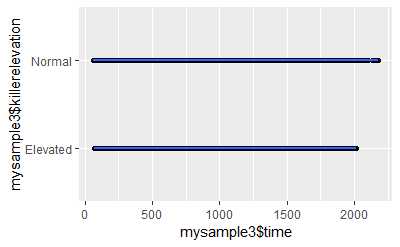

```r
scatterplot_func(mysample3, mysample3$time, mysample3$killerelevation)
```

```r
scatterplot_func(mysample3, mysample3$time, mysample3$GunType)
scatterplot_func(mysample3, mysample3$time, mysample3$killerelevation)
```

[output not shown]

Creating one hot encoding for gun type and elevation

```r
corval <- cor(temp)
round(corval,3)
```

```
                         killer_position_x killer_position_y victim_position_x victim_position_y   time killdistance GunType.Explosives GunType.Machine.Gun
killer_position_x                    1.000             0.104             0.999             0.104 -0.060       -0.024              0.007              -0.008
killer_position_y                    0.104             1.000             0.104             0.999 -0.068       -0.009             -0.014               0.005
victim_position_x                    0.999             0.104             1.000             0.104 -0.060       -0.024              0.007              -0.008
victim_position_y                    0.104             0.999             0.104             1.000 -0.068       -0.010             -0.014               0.005
time                                -0.060            -0.068            -0.060            -0.068  1.000        0.341              0.054               0.019
killdistance                        -0.024            -0.009            -0.024            -0.010  0.341        1.000             -0.045              -0.008
GunType.Explosives                   0.007            -0.014             0.007            -0.014  0.054       -0.045              1.000              -0.014
GunType.Machine.Gun                 -0.008             0.005            -0.008             0.005  0.019       -0.008             -0.014               1.000
GunType.Melee                        0.003            -0.001             0.003            -0.001 -0.170       -0.091             -0.028              -0.016
GunType.Pistol                       0.013            -0.014             0.013            -0.014 -0.180       -0.087             -0.031              -0.017
GunType.Rifle                       -0.012            -0.008            -0.012            -0.009  0.285        0.119             -0.178              -0.100
GunType.Shotgun                      0.017             0.024             0.017             0.024 -0.272       -0.171             -0.058              -0.033
GunType.Sniper                      -0.006             0.022            -0.006             0.023  0.180        0.318             -0.045              -0.026
GunType.Sub.Machine.Gun             -0.001            -0.018            -0.001            -0.018 -0.161       -0.135             -0.059              -0.034
GunType.Vehicles                    -0.005             0.007            -0.005             0.007  0.033       -0.025             -0.023              -0.013
killerelevation.Elevated             0.033             0.346             0.033             0.345  0.014        0.006             -0.002               0.009
killerelevation.Normal              -0.033            -0.346            -0.033            -0.345 -0.014       -0.006              0.002              -0.009
victimelevation.Elevated             0.035             0.346             0.035             0.346  0.012        0.006             -0.005               0.005
victimelevation.Normal              -0.035            -0.346            -0.035            -0.346 -0.012       -0.006              0.005              -0.005
                         GunType.Melee GunType.Pistol GunType.Rifle GunType.Shotgun GunType.Sniper GunType.Sub.Machine.Gun GunType.Vehicles killerelevation.Elevated
killer_position_x                0.003          0.013        -0.012           0.017         -0.006                  -0.001           -0.005                    0.033
killer_position_y               -0.001         -0.014        -0.008           0.024          0.022                  -0.018            0.007                    0.346
victim_position_x                0.003          0.013        -0.012           0.017         -0.006                  -0.001           -0.005                    0.033
victim_position_y               -0.001         -0.014        -0.009           0.024          0.023                  -0.018            0.007                    0.345
time                            -0.170         -0.180         0.285          -0.272          0.180                  -0.161            0.033                    0.014
```

[output cut: 34 more lines]

Splitting data into test set and training set

```r
set.seed(250)
index1 <- createDataPartition(mysample1$GunType, p=0.75, list = FALSE)
mysample1_train<-mysample1[index1,]
mysample1_test<-mysample1[-index1,]

set.seed(250)
index2 <- createDataPartition(mysample2$GunType, p=0.75, list = FALSE)
mysample2_train<-mysample2[index2,]
mysample2_test<-mysample2[-index2,]

set.seed(250)
index3 <- createDataPartition(mysample3$GunType, p=0.75, list = FALSE)
mysample3_train<-mysample3[index3,]
mysample3_test<-mysample3[-index3,]
```

kNN on non scaled data

```r
set.seed(400)
training_control <- trainControl(method = "repeatedcv", number=10, repeats = 3)
#knn <- readRDS("./knn_salesnormalized_model.rds")
knn1 <- train(GunType ~. - killed_by, data = mysample1_train, method = "knn", metric = "Kappa",  trControl = training_control) #,

knn_pred1 <- predict(knn1, newdata = mysample1_test)

confusionMatrix(knn_pred1,mysample1_test$GunType)
```

```
Confusion Matrix and Statistics

                 Reference
Prediction        Explosives Machine Gun Melee Pistol Rifle Shotgun Sniper Sub Machine Gun Vehicles
  Explosives               0           0     2      0    12       5      2               4        0
  Machine Gun              0           0     0      0     4       1      1               1        0
  Melee                    2           0    16      9    50      20      6              14        4
  Pistol                   2           1    14     14    63      39      3              26        4
  Rifle                  139          46   123    151  3212     493    468             591      131
  Shotgun                 18           8    45     46   396     194     22             171        4
  Sniper                   4           1     1      4   103       4     50               7        4
  Sub Machine Gun         15           3    20     46   337     148     15             114        7
  Vehicles                 1           0     4      1    18       1      3               3        7

Overall Statistics

               Accuracy : 0.4811
                 95% CI : (0.4697, 0.4924)
    No Information Rate : 0.5595
    P-Value [Acc > NIR] : 1

                  Kappa : 0.0912
 Mcnemar's Test P-Value : NA

Statistics by Class:

                     Class: Explosives Class: Machine Gun Class: Melee Class: Pistol Class: Rifle Class: Shotgun Class: Sniper Class: Sub Machine Gun Class: Vehicles
Sensitivity                   0.000000          0.0000000     0.071111      0.051661       0.7657        0.21436      0.087719                0.12245       0.0434783
Specificity                   0.996583          0.9990590     0.985563      0.978968       0.3515        0.89231      0.981524                0.91000       0.9957748
Pos Pred Value                0.000000          0.0000000     0.132231      0.084337       0.5999        0.21460      0.280899                0.16170       0.1842105
Neg Pred Value                0.975779          0.9921239     0.971669      0.964948       0.5415        0.89217      0.928962                0.87973       0.9793566
Prevalence                    0.024140          0.0078688     0.030008      0.036143       0.5595        0.12070      0.076020                0.12417       0.0214724
Detection Rate                0.000000          0.0000000     0.002134      0.001867       0.4284        0.02587      0.006668                0.01520       0.0009336
Detection Prevalence          0.003334          0.0009336     0.016138      0.022139       0.7141        0.12057      0.023740                0.09403       0.0050680
Balanced Accuracy             0.498292          0.4995295     0.528337      0.515314       0.5586        0.55334      0.534622                0.51623       0.5196266
```

```r
saveRDS(knn, "./knn1.rds")

set.seed(777)

#knn <- readRDS("./knn_salesnormalized_model.rds")
knn2 <- train(GunType ~.  - killed_by, data = mysample2_train, method = "knn", metric = "Kappa",  trControl = training_control) #,

knn_pred2 <- predict(knn2, newdata = mysample2_test)

confusionMatrix(knn_pred2,mysample2_test$GunType)
```

```
Confusion Matrix and Statistics

                 Reference
Prediction        Explosives Machine Gun Melee Pistol Rifle Shotgun Sniper Sub Machine Gun Vehicles
  Explosives               0           0     2      2    16       1      1               4        0
  Machine Gun              0           0     0      1     2       1      0               1        0
  Melee                    2           0    15      8    33      26      4               8        0
  Pistol                   3           1    11     11    44      37      7              20        2
  Rifle                  132          44   134    146  3251     513    466             619      134
  Shotgun                 19          10    46     63   366     215     15             195        4
  Sniper                   1           2     3      0    96       4     38              13        4
  Sub Machine Gun         19           1    21     40   344     119     17             103        8
  Vehicles                 2           0     0      0    20       0      1               4        3

Overall Statistics

               Accuracy : 0.4849
                 95% CI : (0.4736, 0.4963)
    No Information Rate : 0.5564
    P-Value [Acc > NIR] : 1

                  Kappa : 0.0913
 Mcnemar's Test P-Value : NA

Statistics by Class:

                     Class: Explosives Class: Machine Gun Class: Melee Class: Pistol Class: Rifle Class: Shotgun Class: Sniper Class: Sub Machine Gun Class: Vehicles
Sensitivity                   0.000000          0.0000000     0.064655      0.040590       0.7792        0.23472      0.069217                0.10651       0.0193548
Specificity                   0.996448          0.9993280     0.988852      0.982704       0.3422        0.89091      0.982300                0.91288       0.9963230
Pos Pred Value                0.000000          0.0000000     0.156250      0.080882       0.5977        0.23044      0.236025                0.15327       0.1000000
Neg Pred Value                0.976178          0.9922594     0.970684      0.964684       0.5527        0.89322      0.930353                0.87343       0.9796465
Prevalence                    0.023740          0.0077354     0.030942      0.036143       0.5564        0.12217      0.073220                0.12897       0.0206722
Detection Rate                0.000000          0.0000000     0.002001      0.001467       0.4336        0.02867      0.005068                0.01374       0.0004001
Detection Prevalence          0.003468          0.0006668     0.012803      0.018138       0.7254        0.12443      0.021472                0.08962       0.0040011
Balanced Accuracy             0.498224          0.4996640     0.526754      0.511647       0.5607        0.56282      0.525758                0.50970       0.5078389
```

```r
saveRDS(knn, "./knn2.rds")

set.seed(111)

#knn <- readRDS("./knn_salesnormalized_model.rds")
knn3 <- train(GunType ~.  - killed_by, data = mysample3_train, method = "knn", metric = "Kappa",  trControl = training_control) #,

knn_pred3 <- predict(knn3, newdata = mysample3_test)

confusionMatrix(knn_pred3,mysample3_test$GunType)
```

```
Confusion Matrix and Statistics

                 Reference
Prediction        Explosives Machine Gun Melee Pistol Rifle Shotgun Sniper Sub Machine Gun Vehicles
  Explosives               2           0     0      3    17       5      1               4        1
  Machine Gun              0           0     0      0     1       0      0               0        0
  Melee                    3           0    18      7    58      23      4              21        1
  Pistol                   3           1    11     12    69      25      2              25        0
  Rifle                  135          42   119    143  3240     512    466             582      127
  Shotgun                 16           4    58     60   388     225     26             165        9
  Sniper                   2           1     1      0    89       5     44               4        3
  Sub Machine Gun         10           4    21     48   306     131     20             134       10
  Vehicles                 1           0     2      0    19       2      0               2        3

Overall Statistics

               Accuracy : 0.4907
                 95% CI : (0.4793, 0.502)
    No Information Rate : 0.5586
    P-Value [Acc > NIR] : 1

                  Kappa : 0.1066
 Mcnemar's Test P-Value : NA

Statistics by Class:

                     Class: Explosives Class: Machine Gun Class: Melee Class: Pistol Class: Rifle Class: Shotgun Class: Sniper Class: Sub Machine Gun Class: Vehicles
Sensitivity                  0.0116279          0.0000000     0.078261      0.043956       0.7738        0.24246       0.07815                0.14301       0.0194805
Specificity                  0.9957673          0.9998657     0.983898      0.981171       0.3575        0.88946       0.98486                0.91615       0.9964587
Pos Pred Value               0.0606061          0.0000000     0.133333      0.081081       0.6038        0.23659       0.29530                0.19591       0.1034483
Neg Pred Value               0.9772210          0.9930620     0.971200      0.964480       0.5554        0.89259       0.92936                0.88212       0.9797777
Prevalence                   0.0229456          0.0069370     0.030683      0.036419       0.5586        0.12380       0.07511                0.12500       0.0205443
Detection Rate               0.0002668          0.0000000     0.002401      0.001601       0.4322        0.03002       0.00587                0.01788       0.0004002
Detection Prevalence         0.0044023          0.0001334     0.018010      0.019744       0.7158        0.12687       0.01988                0.09125       0.0038687
Balanced Accuracy            0.5036976          0.4999328     0.531079      0.512564       0.5657        0.56596       0.53150                0.52958       0.5079696
```

```r
saveRDS(knn, "./knn3.rds")
```

kNN on scaled data

```r
straining_control <- trainControl(method = "repeatedcv", number=10, repeats = 3)
#knn <- readRDS("./knn_salesnormalized_model.rds")
sknn1 <- train(GunType ~., data = smysample1_train, method = "knn", metric = "Kappa",  trControl = straining_control) #,

sknn_pred1 <- predict(sknn1, newdata = smysample1_test)

confusionMatrix(sknn_pred1,smysample1_test$GunType)
```

```
Confusion Matrix and Statistics

                 Reference
Prediction        Explosives Machine Gun Melee Pistol Rifle Shotgun Sniper Sub Machine Gun Vehicles
  Explosives               1           0     3      0    17       5      3               4        0
  Machine Gun              0           0     1      0     6       1      0               1        0
  Melee                    4           0    17      6    51      21      6              15        5
  Pistol                   0           3    14     10    67      30      1              23        3
  Rifle                  139          45   121    151  3213     491    462             600      130
  Shotgun                 18           6    39     50   395     207     25             169        5
  Sniper                   2           1     2      3   108       4     54               7        5
  Sub Machine Gun         15           4    24     50   319     143     16             108        5
  Vehicles                 2           0     4      1    19       3      3               4        8

Overall Statistics

               Accuracy : 0.4825
                 95% CI : (0.4712, 0.4939)
    No Information Rate : 0.5595
    P-Value [Acc > NIR] : 1

                  Kappa : 0.0941
 Mcnemar's Test P-Value : NA

Statistics by Class:

                     Class: Explosives Class: Machine Gun Class: Melee Class: Pistol Class: Rifle Class: Shotgun Class: Sniper Class: Sub Machine Gun Class: Vehicles
Sensitivity                  0.0055249           0.000000     0.075556      0.036900       0.7659        0.22873      0.094737                0.11600        0.049689
Specificity                  0.9956266           0.998790     0.985151      0.980490       0.3524        0.89277      0.980947                0.91229        0.995093
Pos Pred Value               0.0303030           0.000000     0.136000      0.066225       0.6003        0.22648      0.290323                0.15789        0.181818
Neg Pred Value               0.9758875           0.992122     0.971789      0.964475       0.5424        0.89399      0.929431                0.87922        0.979474
Prevalence                   0.0241398           0.007869     0.030008      0.036143       0.5595        0.12070      0.076020                0.12417        0.021472
Detection Rate               0.0001334           0.000000     0.002267      0.001334       0.4285        0.02761      0.007202                0.01440        0.001067
Detection Prevalence         0.0044012           0.001200     0.016671      0.020139       0.7138        0.12190      0.024807                0.09122        0.005868
Balanced Accuracy            0.5005757           0.499395     0.530353      0.508695       0.5592        0.56075      0.537842                0.51415        0.522391
```

Rule learning on non scaled data

```r
set.seed(333)
JRips1 <- JRip(GunType ~ . - killed_by, data = mysample1_train)
predict_Jrips1<-predict(JRips1,mysample1_test)
summary(predict_Jrips1)
```

```
     Explosives     Machine Gun           Melee          Pistol           Rifle         Shotgun          Sniper Sub Machine Gun        Vehicles
             74               0             242               0            7017              53              77               0              35
```

```r
confusionMatrix(predict_Jrips1,mysample1_test$GunType)
```

```
Confusion Matrix and Statistics

                 Reference
Prediction        Explosives Machine Gun Melee Pistol Rifle Shotgun Sniper Sub Machine Gun Vehicles
  Explosives              51           0     0      0     0       0      0               0       23
  Machine Gun              0           0     0      0     0       0      0               0        0
  Melee                    0           1   148     17    31      27      2              14        2
  Pistol                   0           0     0      0     0       0      0               0        0
  Rifle                  114          57    74    251  4109     860    532             903      117
  Shotgun                  0           1     3      3    12      18      2              14        0
  Sniper                   0           0     0      0    43       0     34               0        0
  Sub Machine Gun          0           0     0      0     0       0      0               0        0
  Vehicles                16           0     0      0     0       0      0               0       19

Overall Statistics

               Accuracy : 0.584
                 95% CI : (0.5728, 0.5952)
    No Information Rate : 0.5595
    P-Value [Acc > NIR] : 9.453e-06

                  Kappa : 0.1214
 Mcnemar's Test P-Value : NA

Statistics by Class:

                     Class: Explosives Class: Machine Gun Class: Melee Class: Pistol Class: Rifle Class: Shotgun Class: Sniper Class: Sub Machine Gun Class: Vehicles
Sensitivity                   0.281768           0.000000      0.65778       0.00000       0.9795       0.019890      0.059649                 0.0000        0.118012
Specificity                   0.996857           1.000000      0.98708       1.00000       0.1196       0.994691      0.993793                 1.0000        0.997819
Pos Pred Value                0.689189                NaN      0.61157           NaN       0.5856       0.339623      0.441558                    NaN        0.542857
Neg Pred Value                0.982489           0.992131      0.98939       0.96386       0.8212       0.880860      0.927773                 0.8758        0.980973
Prevalence                    0.024140           0.007869      0.03001       0.03614       0.5595       0.120699      0.076020                 0.1242        0.021472
Detection Rate                0.006802           0.000000      0.01974       0.00000       0.5480       0.002401      0.004535                 0.0000        0.002534
Detection Prevalence          0.009869           0.000000      0.03228       0.00000       0.9358       0.007069      0.010269                 0.0000        0.004668
Balanced Accuracy             0.639312           0.500000      0.82243       0.50000       0.5495       0.507290      0.526721                 0.5000        0.557916
```

```r
saveRDS(JRips1, "./Jrips1.rds")


set.seed(222)
JRips2 <- JRip(GunType ~ . - killed_by, data = mysample2_train)
predict_Jrips2<-predict(JRips2,mysample2_test)
summary(predict_Jrips2)
```

```
     Explosives     Machine Gun           Melee          Pistol           Rifle         Shotgun          Sniper Sub Machine Gun        Vehicles
             91               0             212               9            7145               0              25               0              16
```

```r
confusionMatrix(predict_Jrips2,mysample2_test$GunType)
```

```
Confusion Matrix and Statistics

                 Reference
Prediction        Explosives Machine Gun Melee Pistol Rifle Shotgun Sniper Sub Machine Gun Vehicles
  Explosives              58           0     0      0     1       0      0               0       32
  Machine Gun              0           0     0      0     0       0      0               0        0
  Melee                    0           2   141     12    13      22      4              17        1
  Pistol                   0           0     1      3     1       2      0               0        2
  Rifle                  110          56    90    256  4142     892    535             950      114
  Shotgun                  0           0     0      0     0       0      0               0        0
  Sniper                   0           0     0      0    15       0     10               0        0
  Sub Machine Gun          0           0     0      0     0       0      0               0        0
  Vehicles                10           0     0      0     0       0      0               0        6

Overall Statistics

               Accuracy : 0.5815
                 95% CI : (0.5702, 0.5927)
    No Information Rate : 0.5564
    P-Value [Acc > NIR] : 6.289e-06

                  Kappa : 0.1063
 Mcnemar's Test P-Value : NA

Statistics by Class:

                     Class: Explosives Class: Machine Gun Class: Melee Class: Pistol Class: Rifle Class: Shotgun Class: Sniper Class: Sub Machine Gun Class: Vehicles
Sensitivity                   0.325843           0.000000      0.60776     0.0110701      0.99281         0.0000      0.018215                  0.000       0.0387097
Specificity                   0.995492           1.000000      0.99023     0.9991698      0.09711         1.0000      0.997841                  1.000       0.9986382
Pos Pred Value                0.637363                NaN      0.66509     0.3333333      0.57971            NaN      0.400000                    NaN       0.3750000
Neg Pred Value                0.983799           0.992265      0.98751     0.9642142      0.91501         0.8778      0.927874                  0.871       0.9800855
Prevalence                    0.023740           0.007735      0.03094     0.0361430      0.55642         0.1222      0.073220                  0.129       0.0206722
Detection Rate                0.007735           0.000000      0.01881     0.0004001      0.55241         0.0000      0.001334                  0.000       0.0008002
Detection Prevalence          0.012137           0.000000      0.02827     0.0012003      0.95292         0.0000      0.003334                  0.000       0.0021339
Balanced Accuracy             0.660667           0.500000      0.79899     0.5051199      0.54496         0.5000      0.508028                  0.500       0.5186739
```

```r
saveRDS(JRips2, "./Jrips2.rds")


set.seed(444)
JRips3 <- JRip(GunType ~ . - killed_by, data = mysample3_train)
predict_Jrips3<-predict(JRips3,mysample3_test)
summary(predict_Jrips3)
```

```
     Explosives     Machine Gun           Melee          Pistol           Rifle         Shotgun          Sniper Sub Machine Gun        Vehicles
             59               0             224               0            7133               0              33               0              47
```

```r
confusionMatrix(predict_Jrips3,mysample3_test$GunType)
```

```
Confusion Matrix and Statistics

                 Reference
Prediction        Explosives Machine Gun Melee Pistol Rifle Shotgun Sniper Sub Machine Gun Vehicles
  Explosives              45           0     0      0     0       0      0               0       14
  Machine Gun              0           0     0      0     0       0      0               0        0
  Melee                    2           0   146      9    25      19      5              16        2
  Pistol                   0           0     0      0     0       0      0               0        0
  Rifle                  103          52    83    264  4137     909    550             919      116
  Shotgun                  0           0     0      0     0       0      0               0        0
  Sniper                   0           0     0      0    25       0      8               0        0
  Sub Machine Gun          0           0     0      0     0       0      0               0        0
  Vehicles                22           0     1      0     0       0      0               2       22

Overall Statistics

               Accuracy : 0.5814
                 95% CI : (0.5701, 0.5926)
    No Information Rate : 0.5586
    P-Value [Acc > NIR] : 3.545e-05

                  Kappa : 0.1035
 Mcnemar's Test P-Value : NA

Statistics by Class:

                     Class: Explosives Class: Machine Gun Class: Melee Class: Pistol Class: Rifle Class: Shotgun Class: Sniper Class: Sub Machine Gun Class: Vehicles
Sensitivity                   0.261628           0.000000      0.63478       0.00000      0.98806         0.0000      0.014210                  0.000        0.142857
Specificity                   0.998088           1.000000      0.98927       1.00000      0.09459         1.0000      0.996394                  1.000        0.996595
Pos Pred Value                0.762712                NaN      0.65179           NaN      0.57998            NaN      0.242424                    NaN        0.468085
Neg Pred Value                0.982923           0.993063      0.98845       0.96358      0.86226         0.8762      0.925633                  0.875        0.982280
Prevalence                    0.022946           0.006937      0.03068       0.03642      0.55856         0.1238      0.075107                  0.125        0.020544
Detection Rate                0.006003           0.000000      0.01948       0.00000      0.55189         0.0000      0.001067                  0.000        0.002935
Detection Prevalence          0.007871           0.000000      0.02988       0.00000      0.95157         0.0000      0.004402                  0.000        0.006270
Balanced Accuracy             0.629858           0.500000      0.81202       0.50000      0.54132         0.5000      0.505302                  0.500        0.569726
```

```r
saveRDS(JRips3, "./Jrips3.rds")
```

```r
set.seed(333)
sJRips1 <- JRip(GunType ~ . - killed_by, data = smysample1_train)
spredict_Jrips1<-predict(sJRips1,smysample1_test)
summary(spredict_Jrips1)
```

```
     Explosives     Machine Gun           Melee          Pistol           Rifle         Shotgun          Sniper Sub Machine Gun        Vehicles
             74               0             242               0            7017              53              77               0              35
```

```r
confusionMatrix(spredict_Jrips1,smysample1_test$GunType)
```

```
Confusion Matrix and Statistics

                 Reference
Prediction        Explosives Machine Gun Melee Pistol Rifle Shotgun Sniper Sub Machine Gun Vehicles
  Explosives              51           0     0      0     0       0      0               0       23
  Machine Gun              0           0     0      0     0       0      0               0        0
  Melee                    0           1   148     17    31      27      2              14        2
  Pistol                   0           0     0      0     0       0      0               0        0
  Rifle                  114          57    74    251  4109     860    532             903      117
  Shotgun                  0           1     3      3    12      18      2              14        0
  Sniper                   0           0     0      0    43       0     34               0        0
  Sub Machine Gun          0           0     0      0     0       0      0               0        0
  Vehicles                16           0     0      0     0       0      0               0       19

Overall Statistics

               Accuracy : 0.584
                 95% CI : (0.5728, 0.5952)
    No Information Rate : 0.5595
    P-Value [Acc > NIR] : 9.453e-06

                  Kappa : 0.1214
 Mcnemar's Test P-Value : NA

Statistics by Class:

                     Class: Explosives Class: Machine Gun Class: Melee Class: Pistol Class: Rifle Class: Shotgun Class: Sniper Class: Sub Machine Gun Class: Vehicles
Sensitivity                   0.281768           0.000000      0.65778       0.00000       0.9795       0.019890      0.059649                 0.0000        0.118012
Specificity                   0.996857           1.000000      0.98708       1.00000       0.1196       0.994691      0.993793                 1.0000        0.997819
Pos Pred Value                0.689189                NaN      0.61157           NaN       0.5856       0.339623      0.441558                    NaN        0.542857
Neg Pred Value                0.982489           0.992131      0.98939       0.96386       0.8212       0.880860      0.927773                 0.8758        0.980973
Prevalence                    0.024140           0.007869      0.03001       0.03614       0.5595       0.120699      0.076020                 0.1242        0.021472
Detection Rate                0.006802           0.000000      0.01974       0.00000       0.5480       0.002401      0.004535                 0.0000        0.002534
Detection Prevalence          0.009869           0.000000      0.03228       0.00000       0.9358       0.007069      0.010269                 0.0000        0.004668
Balanced Accuracy             0.639312           0.500000      0.82243       0.50000       0.5495       0.507290      0.526721                 0.5000        0.557916
```

```r
sJRips1
```

```
JRIP rules:
===========

(killdistance <= 1.552417) and (time >= 537) and (killer_position_x <= 334228.4) => GunType=Vehicles (51.0/23.0)
(killdistance <= 0) and (time >= 704) and (killer_position_y >= 367525.4) and (time <= 847) => GunType=Vehicles (19.0/6.0)
(killdistance <= 1.389244) and (time >= 914) and (killer_position_y <= 210491.7) => GunType=Vehicles (7.0/1.0)
(killdistance <= 0) => GunType=Explosives (254.0/73.0)
(killdistance <= 98.595588) and (time <= 174) and (killer_position_x <= 354326.3) => GunType=Melee (115.0/21.0)
(killdistance <= 131.158263) and (time <= 128) => GunType=Melee (314.0/108.0)
(killdistance <= 93.407708) and (time <= 284) and (killdistance >= 78.751317) => GunType=Melee (190.0/69.0)
(killdistance <= 115.702031) and (killer_position_x >= 488458.7) and (killer_position_x <= 535550.8) => GunType=Melee (17.0/6.0)
(killdistance <= 128.232016) and (time <= 160) and (killer_position_x >= 432195.8) => GunType=Melee (37.0/18.0)
(killdistance >= 9867.813132) and (time >= 1678) and (killdistance <= 15483.686419) => GunType=Sniper (166.0/81.0)
(killdistance >= 10981.405343) and (killer_position_y >= 322453.1) and (killer_position_y <= 369829.1) and (time >= 1505) => GunType=Sniper (55.0/23.0)
(killdistance <= 1043.960708) and (killer_position_y >= 414874.8) and (victim_position_y <= 627478.2) and (victim_position_y >= 613295.3) and (killdistance >= 242.88699) and (time <= 138) and (victim_position_x <= 451097.7) => GunType=Shotgun (59.0/18.0)
(time <= 268) and (killdistance <= 685.914936) and (killdistance >= 603.52299) and (killer_position_x >= 420193.6) and (victim_position_y >= 325850.6) => GunType=Shotgun (111.0/51.0)
 => GunType=Rifle (21107.0/8738.0)

Number of Rules : 14
```

Rparts on non scaled data

```r
set.seed(101)
r_ctrl <- trainControl(method="repeatedcv", number = 5, repeats = 3)

rparts1 <- train(GunType ~ .  - killed_by, data = mysample1_train, method = "rpart", trControl = r_ctrl, tuneLength = 5, metric = "Kappa")
rparts_pred1 <- predict(rparts1, newdata = mysample1_test)
confusionMatrix(rparts_pred1, mysample1_test$GunType)
```

```
Confusion Matrix and Statistics

                 Reference
Prediction        Explosives Machine Gun Melee Pistol Rifle Shotgun Sniper Sub Machine Gun Vehicles
  Explosives              67           0     0      0     0       0      0               0       43
  Machine Gun              0           0     0      0     0       0      0               0        0
  Melee                    1           1   167     24    40      49      3              21        4
  Pistol                   0           0     0      0     0       0      0               0        0
  Rifle                  110          53    32    102  3861     526    533             717      101
  Shotgun                  3           5    26    145   294     330     34             193       13
  Sniper                   0           0     0      0     0       0      0               0        0
  Sub Machine Gun          0           0     0      0     0       0      0               0        0
  Vehicles                 0           0     0      0     0       0      0               0        0

Overall Statistics

               Accuracy : 0.5902
                 95% CI : (0.5789, 0.6013)
    No Information Rate : 0.5595
    P-Value [Acc > NIR] : 4.323e-08

                  Kappa : 0.2286
 Mcnemar's Test P-Value : NA

Statistics by Class:

                     Class: Explosives Class: Machine Gun Class: Melee Class: Pistol Class: Rifle Class: Shotgun Class: Sniper Class: Sub Machine Gun Class: Vehicles
Sensitivity                   0.370166           0.000000      0.74222       0.00000       0.9204        0.36464       0.00000                 0.0000         0.00000
Specificity                   0.994123           1.000000      0.98034       1.00000       0.3418        0.89185       1.00000                 1.0000         1.00000
Pos Pred Value                0.609091                NaN      0.53871           NaN       0.6398        0.31640           NaN                    NaN             NaN
Neg Pred Value                0.984570           0.992131      0.99193       0.96386       0.7717        0.91092       0.92398                 0.8758         0.97853
Prevalence                    0.024140           0.007869      0.03001       0.03614       0.5595        0.12070       0.07602                 0.1242         0.02147
Detection Rate                0.008936           0.000000      0.02227       0.00000       0.5149        0.04401       0.00000                 0.0000         0.00000
Detection Prevalence          0.014671           0.000000      0.04134       0.00000       0.8049        0.13910       0.00000                 0.0000         0.00000
Balanced Accuracy             0.682145           0.500000      0.86128       0.50000       0.6311        0.62825       0.50000                 0.5000         0.50000
```

```r
saveRDS(rparts1, "./rparts1")

set.seed(9811)
rparts2 <- train(GunType ~ .  - killed_by, data = mysample2_train, method = "rpart", trControl = r_ctrl, tuneLength = 5, metric = "Kappa")
rparts_pred2 <- predict(rparts2, newdata = mysample2_test)
confusionMatrix(rparts_pred2, mysample2_test$GunType)
```

```
Confusion Matrix and Statistics

                 Reference
Prediction        Explosives Machine Gun Melee Pistol Rifle Shotgun Sniper Sub Machine Gun Vehicles
  Explosives              68           0     0      0     1       0      0               0       40
  Machine Gun              0           0     0      0     0       0      0               0        0
  Melee                    1           1   166     17    43      35      6              34        3
  Pistol                   0           0     0      0     0       0      0               0        0
  Rifle                  102          50    29    108  3781     514    515             696      104
  Shotgun                  7           7    37    146   347     367     28             237        8
  Sniper                   0           0     0      0     0       0      0               0        0
  Sub Machine Gun          0           0     0      0     0       0      0               0        0
  Vehicles                 0           0     0      0     0       0      0               0        0

Overall Statistics

               Accuracy : 0.5844
                 95% CI : (0.5732, 0.5956)
    No Information Rate : 0.5564
    P-Value [Acc > NIR] : 5.273e-07

                  Kappa : 0.2323
 Mcnemar's Test P-Value : NA

Statistics by Class:

                     Class: Explosives Class: Machine Gun Class: Melee Class: Pistol Class: Rifle Class: Shotgun Class: Sniper Class: Sub Machine Gun Class: Vehicles
Sensitivity                   0.382022           0.000000      0.71552       0.00000       0.9063        0.40066       0.00000                  0.000         0.00000
Specificity                   0.994399           1.000000      0.98073       1.00000       0.3632        0.87587       1.00000                  1.000         1.00000
Pos Pred Value                0.623853                NaN      0.54248           NaN       0.6410        0.30997           NaN                    NaN             NaN
Neg Pred Value                0.985113           0.992265      0.99082       0.96386       0.7555        0.91305       0.92678                  0.871         0.97933
Prevalence                    0.023740           0.007735      0.03094       0.03614       0.5564        0.12217       0.07322                  0.129         0.02067
Detection Rate                0.009069           0.000000      0.02214       0.00000       0.5043        0.04895       0.00000                  0.000         0.00000
Detection Prevalence          0.014537           0.000000      0.04081       0.00000       0.7867        0.15791       0.00000                  0.000         0.00000
Balanced Accuracy             0.688211           0.500000      0.84812       0.50000       0.6347        0.63826       0.50000                  0.500         0.50000
```

```r
saveRDS(rparts2, "./rparts2")

set.seed(5975)
rparts3 <- train(GunType ~ .  - killed_by, data = mysample3_train, method = "rpart", trControl = r_ctrl, tuneLength = 5, metric = "Kappa")
rparts_pred3 <- predict(rparts3, newdata = mysample3_test)
confusionMatrix(rparts_pred3, mysample3_test$GunType)
```

```
Confusion Matrix and Statistics

                 Reference
Prediction        Explosives Machine Gun Melee Pistol Rifle Shotgun Sniper Sub Machine Gun Vehicles
  Explosives              67           0     0      0     1       0      0               2       36
  Machine Gun              0           0     0      0     0       0      0               0        0
  Melee                    3           0   178     14    40      47      6              29        1
  Pistol                   0           0     0      0     0       0      0               0        0
  Rifle                  101          46    31    134  3924     646    537             763      109
  Shotgun                  1           6    21    125   222     235     20             143        8
  Sniper                   0           0     0      0     0       0      0               0        0
  Sub Machine Gun          0           0     0      0     0       0      0               0        0
  Vehicles                 0           0     0      0     0       0      0               0        0

Overall Statistics

               Accuracy : 0.5875
                 95% CI : (0.5763, 0.5987)
    No Information Rate : 0.5586
    P-Value [Acc > NIR] : 2.228e-07

                  Kappa : 0.2017
 Mcnemar's Test P-Value : NA

Statistics by Class:

                     Class: Explosives Class: Machine Gun Class: Melee Class: Pistol Class: Rifle Class: Shotgun Class: Sniper Class: Sub Machine Gun Class: Vehicles
Sensitivity                   0.389535           0.000000      0.77391       0.00000       0.9372        0.25323       0.00000                  0.000         0.00000
Specificity                   0.994675           1.000000      0.98073       1.00000       0.2847        0.91687       1.00000                  1.000         1.00000
Pos Pred Value                0.632075                NaN      0.55975           NaN       0.6237        0.30090           NaN                    NaN             NaN
Neg Pred Value                0.985792           0.993063      0.99276       0.96358       0.7817        0.89680       0.92489                  0.875         0.97946
Prevalence                    0.022946           0.006937      0.03068       0.03642       0.5586        0.12380       0.07511                  0.125         0.02054
Detection Rate                0.008938           0.000000      0.02375       0.00000       0.5235        0.03135       0.00000                  0.000         0.00000
Detection Prevalence          0.014141           0.000000      0.04242       0.00000       0.8392        0.10419       0.00000                  0.000         0.00000
Balanced Accuracy             0.692105           0.500000      0.87732       0.50000       0.6109        0.58505       0.50000                  0.500         0.50000
```

```r
saveRDS(rparts3, "./rparts3")
```

```r
confusionMatrix(srparts_pred1, smysample1_test$GunType)
```

```
Confusion Matrix and Statistics

                 Reference
Prediction        Explosives Machine Gun Melee Pistol Rifle Shotgun Sniper Sub Machine Gun Vehicles
  Explosives              67           0     0      0     0       0      0               0       43
  Machine Gun              0           0     0      0     0       0      0               0        0
  Melee                    1           1   167     24    40      49      3              21        4
  Pistol                   0           0     0      0     0       0      0               0        0
  Rifle                  110          53    32    102  3861     526    533             717      101
  Shotgun                  3           5    26    145   294     330     34             193       13
  Sniper                   0           0     0      0     0       0      0               0        0
  Sub Machine Gun          0           0     0      0     0       0      0               0        0
  Vehicles                 0           0     0      0     0       0      0               0        0

Overall Statistics

               Accuracy : 0.5902
                 95% CI : (0.5789, 0.6013)
    No Information Rate : 0.5595
    P-Value [Acc > NIR] : 4.323e-08

                  Kappa : 0.2286
 Mcnemar's Test P-Value : NA

Statistics by Class:

                     Class: Explosives Class: Machine Gun Class: Melee Class: Pistol Class: Rifle Class: Shotgun Class: Sniper Class: Sub Machine Gun Class: Vehicles
Sensitivity                   0.370166           0.000000      0.74222       0.00000       0.9204        0.36464       0.00000                 0.0000         0.00000
Specificity                   0.994123           1.000000      0.98034       1.00000       0.3418        0.89185       1.00000                 1.0000         1.00000
Pos Pred Value                0.609091                NaN      0.53871           NaN       0.6398        0.31640           NaN                    NaN             NaN
Neg Pred Value                0.984570           0.992131      0.99193       0.96386       0.7717        0.91092       0.92398                 0.8758         0.97853
Prevalence                    0.024140           0.007869      0.03001       0.03614       0.5595        0.12070       0.07602                 0.1242         0.02147
Detection Rate                0.008936           0.000000      0.02227       0.00000       0.5149        0.04401       0.00000                 0.0000         0.00000
Detection Prevalence          0.014671           0.000000      0.04134       0.00000       0.8049        0.13910       0.00000                 0.0000         0.00000
Balanced Accuracy             0.682145           0.500000      0.86128       0.50000       0.6311        0.62825       0.50000                 0.5000         0.50000
```

SVM on scaled data

```r
set.seed(7000)
svm3<- svm(GunType~.  - killed_by, data = mysample3_train, scale=TRUE, kernel = "radial", cross = 3)

svm_predict3<-predict(svm3,mysample3_test)
confusionMatrix(svm_predict3,mysample3_test$GunType)
```

```
Confusion Matrix and Statistics

                 Reference
Prediction        Explosives Machine Gun Melee Pistol Rifle Shotgun Sniper Sub Machine Gun Vehicles
  Explosives               0           0     0      0     0       0      0               0        0
  Machine Gun              0           0     0      0     0       0      0               0        0
  Melee                    0           0     0      0     0       0      0               0        0
  Pistol                   0           0     0      0     0       0      0               0        0
  Rifle                  172          52   230    273  4187     928    563             937      154
  Shotgun                  0           0     0      0     0       0      0               0        0
  Sniper                   0           0     0      0     0       0      0               0        0
  Sub Machine Gun          0           0     0      0     0       0      0               0        0
  Vehicles                 0           0     0      0     0       0      0               0        0

Overall Statistics

               Accuracy : 0.5586
                 95% CI : (0.5472, 0.5698)
    No Information Rate : 0.5586
    P-Value [Acc > NIR] : 0.5048

                  Kappa : 0
 Mcnemar's Test P-Value : NA

Statistics by Class:

                     Class: Explosives Class: Machine Gun Class: Melee Class: Pistol Class: Rifle Class: Shotgun Class: Sniper Class: Sub Machine Gun Class: Vehicles
Sensitivity                    0.00000           0.000000      0.00000       0.00000       1.0000         0.0000       0.00000                  0.000         0.00000
Specificity                    1.00000           1.000000      1.00000       1.00000       0.0000         1.0000       1.00000                  1.000         1.00000
Pos Pred Value                     NaN                NaN          NaN           NaN       0.5586            NaN           NaN                    NaN             NaN
Neg Pred Value                 0.97705           0.993063      0.96932       0.96358          NaN         0.8762       0.92489                  0.875         0.97946
Prevalence                     0.02295           0.006937      0.03068       0.03642       0.5586         0.1238       0.07511                  0.125         0.02054
Detection Rate                 0.00000           0.000000      0.00000       0.00000       0.5586         0.0000       0.00000                  0.000         0.00000
Detection Prevalence           0.00000           0.000000      0.00000       0.00000       1.0000         0.0000       0.00000                  0.000         0.00000
Balanced Accuracy              0.50000           0.500000      0.50000       0.50000       0.5000         0.5000       0.50000                  0.500         0.50000
```